# Probability Base

Alene Onion

22 October, 2024

# Probability analysis

## Load packages

```r
library(tidyverse)
library(huxtable)
library(ggplot2)
library(lubridate)
library(ggbreak)
library(spsurvey) #This code was written for spsurvey v5.0.0
```

## Load data

To run cat_analysis(), the dataframe will need to include columns for the categorical variable you are interested in, weight for each site, xcoordinate and ycoordinate. Optionally, you can also include a subpopulation or stratum column to separate results and site IDs for two-stage analysis (for example, if there are repeated sites).

In this script, weight is adjusted because of the proportional design. In the future, this can be excluded as the design should include weights already.

Epilimnetic values are used to compare across lake types. Dissolved oxygen and ph values are synthesized by the stay calm package to represent a single value for an event.

```r
# read in site data
sites<-read.csv("Probability_Based_Sites_2020_2021.csv")
sites<-sites %>%
  mutate(SITE_CODE=gsub("^$|^ $", NA, LAKE_ID)) |>
  mutate(SITE_CODE=ifelse(!is.na(SITE_CODE),paste(SITE_CODE,"_DH",sep=""),NA)) |>
  mutate(SITE_CODE=ifelse(SITE_CODE=="0704CAN0286_DH","0704CAN0286_CSL1",SITE_CODE)) |>
  rename(siteID=SITE_ID,
         xcoord=LON_DD83,
         ycoord=LAT_DD83,
         Eval_Status=EvalStatus) %>%
  filter(Eval_Status!="") %>%    #removing sites that we haven't yet evaluated
  mutate(Eval_Status=trimws(Eval_Status))

df<-obt |>
  #convert true color flags to A
  mutate(RESULT_QUALIFIER=ifelse(PARAMETER_NAME=="true_color","A",RESULT_QUALIFIER)) |>
  filter(
    SAMPLE_LOCATION %in% c("open_water","depth_profile","secchi_depth"),
    SITE_CODE %in% unique(sites$SITE_CODE),
    WATERBODY_TYPE == "lake",
    EVENT_DATETIME >= as.POSIXct("2020-01-01 00:00"),
    EVENT_DATETIME <= as.POSIXct("2022-01-01 00:00"),
    #remove rejected data
    !RESULT_QUALIFIER %in% c("R", "T"),
    SAMPLE_LAB!="SUNYESF"
    ) |>
  #simplify date and convert non-detect to 0
  mutate(EVENT_DATETIME=as.Date(as.POSIXct(EVENT_DATETIME), tz = ""),
         RESULT_VALUE=ifelse(grepl("U",RESULT_QUALIFIER),0,RESULT_VALUE),
           RESULT_VALUE=ifelse(is.na(RESULT_VALUE),0,RESULT_VALUE)) |>
  #convert two dates sampled by CSLAP and LCI to the same artificially
  mutate(EVENT_DATETIME=as.Date(ifelse(EVENT_DATETIME == "2021-09-13"&SITE_CODE=="0704CAN0286_CSL1",as.character("2021-09-19"),as.character(EVENT_DATETIME))))


#remove these depth profile parameters because they are redundant or we have no thresholds to compare them to
df<-df |>
  filter(!(SAMPLE_LOCATION=="depth_profile"&
             PARAMETER_NAME %in% c("chlorophyll-a","dissolved_oxygen_saturation","oxidation_reduction_potential","phycocyanin"))) |>
  distinct()
# #convert these depth profile to a single epilimnetic value
df<-df |>
  group_by(WATERBODY_CODE,WATERBODY_NAME,EVENT_DATETIME,PARAMETER_NAME,FRACTION) |>
  mutate(depth=min(abs(SAMPLE_DEPTH_METERS - 1.5)),na.rm=TRUE) |>
  ungroup() |>
  filter(case_when(PARAMETER_NAME %in% c("specific_conductance","temperature") ~ depth==(abs(SAMPLE_DEPTH_METERS - 1.5)),
                   TRUE ~ PARAMETER_NAME != "junk")) |>
  select(-depth)

#simplify data set
df<-df |>
  select( WIPWL,
    SITE_CODE,
    EVENT_ID,
    REPLICATE,
    EVENT_DATETIME,
    SAMPLE_LOCATION,
    SAMPLE_SOURCE,
    SAMPLE_ORGANIZATION,
    SAMPLE_DEPTH_METERS,
    SAMPLE_METHOD,
    FRACTION,
    PARAMETER_NAME,
    METHOD_SPECIATION,
    UNIT,
    RESULT_VALUE,
    QUANTITATION_LIMIT,
    RESULT_QUALIFIER,
    RESULT_QUALIFIER_DESCRIPTION
  ) |> distinct()

#randomly restricted to one sample per parameter/lake. These parameters were not necessarily collected on the same day
set.seed(1)
events<-df |>
  select(SITE_CODE,EVENT_DATETIME,PARAMETER_NAME) |> distinct() |>
  group_by(SITE_CODE,PARAMETER_NAME) |>
  slice_sample(n=1) |>
  ungroup()
df<-merge(events,df,by=c('SITE_CODE','EVENT_DATETIME','PARAMETER_NAME'),all.x=TRUE)
```

```r
# Load NYSDEC WQS data from Stay CALM
data("nysdec_wqs", package = "stayCALM")

wqs<-df |>
  filter(
    PARAMETER_NAME %in% c("chlorophyll-a","dissolved_oxygen","ph","phosphorus","temperature"),
    !(FRACTION %in% c("dissolved", "unknown") &
      PARAMETER_NAME %in% "phosphorus"),
    !(UNIT %in% c("rfu", "RFU") & PARAMETER_NAME %in% c("chlorophyll_a", "chlorophyll-a"))) |>
  select(
    seg_id = WIPWL,
    site_id = SITE_CODE,
    sample_id = EVENT_ID,
    replicate = REPLICATE,
    date = EVENT_DATETIME,
    info_type = SAMPLE_LOCATION,
    result_type = SAMPLE_SOURCE,
    data_provider = SAMPLE_ORGANIZATION,
    depth = SAMPLE_DEPTH_METERS,
    sample_method = SAMPLE_METHOD,
    fraction = FRACTION,
    parameter = PARAMETER_NAME,
    method_speciation = METHOD_SPECIATION,
    units = UNIT,
    value = RESULT_VALUE,
    quantitation_limit = QUANTITATION_LIMIT,
    validator_qualifiers = RESULT_QUALIFIER,
    interpreted_qualifiers = RESULT_QUALIFIER_DESCRIPTION
  ) |> distinct() |>
  mutate(
    info_type = dplyr::na_if(info_type, "unknown"),
    # modify parameter names to match the names in the stayCALM WQS table.
    parameter = dplyr::case_match(
      .x = parameter,
      "chlorophyll-a" ~ "chlorophyll_a",
      "fecal_coliform" ~ "fecal_coliforms",
      "phenolics" ~ "phenols",
      "bioassessment_profile" ~ "bap",
      "temperature_of_epilimnion" ~ "temperature",
      "temperature_of_hypolimnion" ~ "temperature",
      .default = parameter
    ),
    parameter = dplyr::case_when(
      grepl("multiplate", sample_method) ~ "bap_multiplate",
      grepl("kick", sample_method) ~ "bap_kick",
      grepl("ponar", sample_method) ~ "bap_ponar",
      .default = parameter
    ),
    units = tolower(units),
    value = case_when(
      # To ug/l from mg/l
      fraction %in% "total" &
        units %in% "mg/l" &
        parameter %in% c("ammonia",
                         "chloride",
                         "fluoride",
                         "nitrate",
                         "nitrite",
                         "phosphorus",
                         "sulfate") ~ value * 1000,
      # To ug/l from ng/l or ppt
      fraction %in% "total" &
        units %in% c("ng/l",
                     "ppt") &
        parameter %in% "mercury" ~ value * 1000,
      # To mg/l from ug/l
      fraction %in% "dissolved" &
        units %in% "ug/l" &
        parameter %in% "total_dissolved_solids" ~ value / 1000,
      fraction %in% "total" &
        units %in% "ug/l" &
        parameter %in% "hardness" ~ value / 1000,
      .default = value
    ),
    units = dplyr::case_when(
      grepl("bap_", parameter) ~ "bap_units",
      units %in% "ph units" ~ "ph_units",
      # To ug/l from mg/l
      fraction %in% "total" &
        units %in% "mg/l" &
        parameter %in% c("ammonia",
                         "chloride",
                         "fluoride",
                         "nitrate",
                         "nitrite",
                         "phosphorus",
                         "sulfate") ~ "ug/l",
      # To ug/l from ng/l or ppt
      fraction %in% "total" &
        units %in% c("ng/l",
                     "ppt") &
        parameter %in% "mercury" ~ "ug/l",
      # To mg/l from ug/l
      fraction %in% "dissolved" &
        units %in% "ug/l" &
        parameter %in% "total_dissolved_solids" ~ "mg/l",
      fraction %in% "total" &
        units %in% "ug/l" &
        parameter %in% "hardness" ~ "mg/l",
      .default = units
    ),
    fraction = dplyr::case_when(
      parameter %in% "chlorophyll_a" ~ "total",
      parameter %in% "dissolved_oxygen" ~ "dissolved",
      parameter %in% c("fecal_coliforms", "ph") ~ "total",
      parameter %in% "phenols" & fraction %in% "total_recoverable" ~ "total",
      # Replace "not_applicable" with "none"-- stayCALM's standard.
      fraction %in% "not_applicable" ~ "none",

      .default = fraction
    ),
    method_speciation = dplyr::case_when(
      method_speciation %in% "as_n" ~ "as n",
      parameter %in% c("phosphorus", "sulfate") ~ "none",
      # Replace "not_applicable" with "none"-- stayCALM's standard.
      method_speciation %in% "not_applicable" ~ "none",
      .default = method_speciation
    ))

#fixes
wqs<-wqs |>
  mutate(info_type=ifelse(info_type=="open_water","ow","dp"))

#identify new waterbodies not on the WIPWL
new_wipwl<-wqs |>
  filter(seg_id=="unknown") |>
  mutate(seg_id=paste(substr(site_id,1,4),"-9999",sep=""),
         class="c",
         water_type="Lake/Reservoir",
         wbcatgry="Unassessed",
         x305b_code="3") |>
  select(seg_id,class,water_type,wbcatgry,x305b_code) |> distinct()
#convert unknown WIPWL to location id
wqs<-wqs |>
  mutate(seg_id=ifelse(seg_id=="unknown",paste(substr(site_id,1,4),"-9999",sep=""),seg_id))
#modify the wipwl_df to include these fake WIPWL
fake_wipwl<-stayCALM::wipwl_df
fake_wipwl<-merge(new_wipwl,fake_wipwl,by=c('seg_id','class','water_type','wbcatgry','x305b_code'),all=TRUE)

#pulling excursion data
lake_wqs<-stayCALM::wqs_violations(
  .data = wqs,
  .period = stayCALM::gen_10_year_period(end_date = "2024-01-01"),
  .targeted_assessment = TRUE,
  .wipwl_df = fake_wipwl,
  .wqs_df = stayCALM::nysdec_wqs,
  .tmdl_df = stayCALM::tmdl_df
)


# Create a data frame of Lake and Reservoir WI/PWL assessments.
lake_wqs <- lake_wqs$violation_data |>
  dplyr::distinct() |>
  dplyr::filter(water_type %in% "Lake/Reservoir") |>
#filter to only fishing use since that applies to all lakes
  dplyr::filter(use=="fishing")

#reformat to match df frame
lake_wqs<-lake_wqs |>
  mutate(seg_id=ifelse(substr(seg_id,6,9)=="9999","unknown",seg_id)) |>
  #removing 6 DO threshold because requires a mean
  filter(!(parameter=="dissolved_oxygen"&statistic=="mean")) |>
  #convert ph parameter name to reflect the threshold
  mutate(parameter=ifelse(parameter=='ph'&threshold=="6.5","ph_low",ifelse(parameter=="ph"&threshold=="8.5","ph_high",parameter))) |>
  mutate(
    WIPWL=seg_id,
    SITE_CODE=site_id,
    EVENT_DATETIME=date,
    SAMPLE_LOCATION="depth_profile",
    FRACTION="not_applicable",
    PARAMETER_NAME=parameter,
    UNIT=units,
    RESULT_VALUE=result
  ) |>
  select(WIPWL,SITE_CODE,EVENT_DATETIME,SAMPLE_LOCATION,FRACTION,PARAMETER_NAME,UNIT,RESULT_VALUE,attaining_wqs) |> distinct()
```

Parameters were removed if there were fewer than 30 sites sampled.

```r
#simplify df now that done with STAY:CALM
df<-df |>
  select(WIPWL,SITE_CODE,EVENT_DATETIME,SAMPLE_LOCATION,FRACTION,PARAMETER_NAME,UNIT,RESULT_VALUE) |> distinct() |>
  #restrict to one sample per parameter/site
  group_by(SITE_CODE,EVENT_DATETIME,SAMPLE_LOCATION,PARAMETER_NAME,FRACTION) |>
  slice_sample(n=1) |>
  ungroup()

#remove dissolved oxygen and ph values so can add in the stay calm calculations
df<-df |>
  filter(!(PARAMETER_NAME %in% c('ph','dissolved_oxygen')))
df<-merge(df,lake_wqs,all=TRUE)

#test for duplicates
# junk<-lake_wqs |> group_by(SITE_CODE,PARAMETER_NAME) |> summarise(n=n()) |> ungroup() |> filter(n>1)

#add fraction to the parameter name
df<-df |>
  mutate(PARAMETER_NAME=ifelse(FRACTION=="not_applicable",PARAMETER_NAME,paste(PARAMETER_NAME,"(",FRACTION,")",sep="")),
         PARAMETER_NAME=ifelse(PARAMETER_NAME=="dissolved_organic_carbon(dissolved)","dissolved_organic_carbon",PARAMETER_NAME),
         PARAMETER_NAME=ifelse(PARAMETER_NAME=="total_organic_carbon(total)","total_organic_carbon",PARAMETER_NAME)) |>
  select(-FRACTION)

#save parameter list
parameters<-df |> select(PARAMETER_NAME) |> distinct() |> arrange(PARAMETER_NAME)

#spread data
df_num<-df %>%
  mutate(PARAMETER_NAME=ifelse(PARAMETER_NAME %in% c('ph_low','ph_high'),'ph',PARAMETER_NAME)) |>
  select(SITE_CODE,EVENT_DATETIME,PARAMETER_NAME,RESULT_VALUE) |> distinct() |>
  spread(PARAMETER_NAME,RESULT_VALUE,fill = NA)

#calculate total nitrogen if not done already
df_num<-df_num |>
  mutate(`nitrogen(total)`=ifelse(!is.na(`kjeldahl_nitrogen(total)`),
                                  (`nitrate-nitrite(total)`+`kjeldahl_nitrogen(total)`),
                                  `nitrogen(total)`))

#parameters with less than 30 samples because that's insufficient samples to run the analysis
parameters<-df_num |>
  pivot_longer(cols=-c(SITE_CODE,EVENT_DATETIME),names_to = "PARAMETER_NAME",values_to="result") |>
  filter(!is.na(result)) |>
  group_by(PARAMETER_NAME) |>
  summarise(n=n()) |>
  ungroup()
remove_parameters<-parameters |>
  filter(n<30)  |> distinct()
print(paste("removing these parameters because there are fewer than 30 sites sampled: ",remove_parameters$PARAMETER_NAME,sep=","))
```

```
## [1] "removing these parameters because there are fewer than 30 sites sampled: ,magnesium(total)"
## [2] "removing these parameters because there are fewer than 30 sites sampled: ,nitrate(total)"
## [3] "removing these parameters because there are fewer than 30 sites sampled: ,nitrite(total)"
## [4] "removing these parameters because there are fewer than 30 sites sampled: ,total_dissolved_nitrogen(dissolved)"
## [5] "removing these parameters because there are fewer than 30 sites sampled: ,turbidity"
## [6] "removing these parameters because there are fewer than 30 sites sampled: ,uv_254(total)"
```

```r
df_num<-df_num |>
  select(!(one_of(remove_parameters$PARAMETER_NAME)))


#spread the categorical data
df_cat<-df |>
  filter(!is.na(attaining_wqs)) |>
  mutate(PARAMETER_NAME=paste(PARAMETER_NAME,"_wqs",sep="")) |>
  select(SITE_CODE,EVENT_DATETIME,PARAMETER_NAME,attaining_wqs) |> distinct() |>
  spread(PARAMETER_NAME,attaining_wqs,fill = NA)
#merge back together
df<-merge(df_num,df_cat,all=TRUE)



###add back in eval status from sites
sites_df<-sites |>
  select(SITE_CODE,siteID,xcoord,ycoord,Eval_Status,PROB_CAT) |> distinct()
df<-merge(df,sites_df,by=c('SITE_CODE'),all = TRUE)

 # rm(list=setdiff(ls(), c("obt","newdata","dictionary",'df','parameters')))
```

Adding Categorical Thresholds

```r
#contextualizing categories
# Zebra Mussel Vulnerability (calcium)
# Nutrients (TOC,DOC,TKN,TP diss, TN)
# Browning (DOC, True Color)
# Trohic State (TP,Chla,secchi_trophic)
# Salt (Chloride, sp cond, sodium)
# Buffering Capacity (alkalinity)
# Water Quality Standards categories

# EPA NLA:
# Trophic state
# Biological indicator: chl a
# Nutrients: TP, N…
# HABs


#creating thresholds
df<-df |>
  # CAN'T do because nitrate only collected in half the samples DIN:TP
  # mutate(DINTP=ifelse(!is.na()&!is.na(),`NITROGEN, NITRATE (AS N)_OW_TOTAL`/`phosphorus(total)`) %>%
  # trophic status
  mutate(phos_trophic=case_when(
    `phosphorus(total)`<=0.01 ~ "oligotrophic",
    between(`phosphorus(total)`,0.01,0.02) ~ "mesotrophic",
    `phosphorus(total)`>=0.02 ~ "eutrophic")) %>%
  mutate(chla_trophic=case_when(
    `chlorophyll-a(total)`<=2 ~ "oligotrophic",
    between(`chlorophyll-a(total)`,2,8) ~ "mesotrophic",
    `chlorophyll-a(total)`>=8 ~ "eutrophic")) %>%
  # EPA thresholds
  mutate(`phosphorus_nla`=case_when(
    `phosphorus(total)`<=0.016 ~ "Good",
    between(`phosphorus(total)`, 0.016, 0.0279) ~ "Fair",
    `phosphorus(total)`>=0.0279 ~ "Poor")) %>%
  mutate(`nitrogen_nla`=case_when(
    `nitrogen(total)`<=0.428 ~ "Good",
    between(`nitrogen(total)`, 0.428, 0.655) ~ "Fair",
    `nitrogen(total)`>=0.655 ~ "Poor")) %>%
  mutate(`chlorophylla_nla`=case_when(
    `chlorophyll-a(total)`<=4.52 ~ "Good",
    between(`chlorophyll-a(total)`, 4.52, 8.43) ~ "Fair",
    `chlorophyll-a(total)`>=8.43 ~ "Poor")) %>%
  # microcystin
  mutate(microcystin=case_when(
    is.na(microcystin) ~"Non-detect",
    microcystin<8 ~ "Microcystin Detected",
    microcystin>=8 ~ "Most disturbed")) %>%
  # dissolved oxygen
  mutate(dissolved_oxygen_nla=case_when(
    dissolved_oxygen<=3 ~ "Poor",
    between(dissolved_oxygen, 3, 5) ~ "Fair",
    dissolved_oxygen>=5 ~ "Good")) %>%
  #nutrient limitation
  mutate(nutrient_limitation=case_when(
    `nitrogen(total)`/`phosphorus(total)`<=10 ~ "N-limited",
    between(`nitrogen(total)`/`phosphorus(total)`, 10, 20) ~ "Co-limited",
    `nitrogen(total)`/`phosphorus(total)`>=20 ~ "P-limited")) %>%
  #secchi
  mutate(secchi_trophic=case_when(
    secchi_disk_depth<=2 ~ "eutrophic",
    between(secchi_disk_depth, 2, 5) ~ "mesotrophic",
    secchi_disk_depth>=5 ~ "oligotrophic")) %>%
  #zebra mussels
  mutate(zebra_mussel_vulnerability=case_when(
    `calcium(total)`<=10 ~ "Not susceptible",
    between(`calcium(total)`, 10, 20) ~ "May be susceptible",
    `calcium(total)`>=20 ~ "Highly susceptible")) %>%
  #cslap
  mutate(conductance=case_when(
    specific_conductance<=125 ~ "Soft",
    between(specific_conductance, 125, 250) ~ "Average",
    specific_conductance>=250 ~ "Hard")) %>%
  mutate(color=case_when(
    `true_color(total)`<=10 ~ "Uncolored",
    between(`true_color(total)`, 10, 30) ~ "Weak",
    `true_color(total)`>=30 ~ "High")) %>%
  mutate(ph_cat=case_when(
    ph<=6.5 ~ "Acidic",
    between(ph, 6.5, 7.5) ~ "Neutral",
    between(ph, 7.5, 8.5) ~ "Slightly alk",
    ph>=8.5 ~ "Highly alk")) %>%
  #Nutrient_Color_Status
  mutate(Nutrient_Color_Status=case_when(
    `phosphorus(total)`<=0.030 & `true_color(total)`<=20 ~ "Blue",
    `phosphorus(total)`>0.030 & `true_color(total)`<=20 ~ "Green",
    `phosphorus(total)`<=0.030 & `true_color(total)`>20 ~ "Brown",
    `phosphorus(total)`>0.030 & `true_color(total)`>20 ~ "Murky"
  )) %>%
  #chloride
  mutate(chloride=case_when(
    `chloride(total)` <= 35 ~ "Low",
    between(`chloride(total)`,35,250) ~ "Medium",
    `chloride(total)` >= 250 ~ "High")) %>%
  #chlorophyll
    #Can't use these because there was no chlorophyll-a-concentration_total reported from UFI for these sites in 2021. I don't know why
  # rename(chlorophyte=`chlorophyll-a-concentration_chlorophyte_green-algae`,
  #        cryptophyta=`chlorophyll-a-concentration_cryptophyta_cryptophytes`,
  #        cyanobacteria=`chlorophyll-a-concentration_cyanobacteria_bluegreen`,
  #        diatoms=`chlorophyll-a-concentration_dinophyta_diatoms`,
  #        probe_total=`chlorophyll-a-concentration_total`) %>%
  # mutate(chlorophyte=case_when(
  #   chlorophyte/probe_total<=0.25 ~ "Low",
  #   between(chlorophyte/probe_total,0.25,0.5) ~ "Medium",
  #   chlorophyte/probe_total>=0.5 ~ "High")) %>%
  # mutate(cryptophyta=case_when(
  #   cryptophyta/probe_total<=0.25 ~ "Low",
  #   between(cryptophyta/probe_total,0.25,0.5) ~ "Medium",
  #   cryptophyta/probe_total>=0.5 ~ "High")) %>%
  # mutate(cyanobacteria=case_when(
  #   cyanobacteria/probe_total<=0.25 ~ "Low",
  #   between(cyanobacteria/probe_total,0.25,0.5) ~ "Medium",
  #   cyanobacteria/probe_total>=0.5 ~ "High")) %>%
  # mutate(dinophyta=case_when(
  #   diatoms/probe_total<=0.25 ~ "Low",
  #   between(diatoms/probe_total,0.25,0.5) ~ "Medium",
  #   diatoms/probe_total>=0.5 ~ "High")) %>%
  #alkalinity
  mutate(alkalinity=case_when(
    `alkalinity(total)` <= 60 ~ "Soft",
    between(`alkalinity(total)`,60,120) ~ "Moderate",
    between(`alkalinity(total)`,120,180) ~ "Hard",
    `alkalinity(total)` >= 180 ~ "Very hard"))
  #WQS dissolved oxygen and ph are already categorical



# Create a Target/NonTarget status variable
df<-df %>%
  mutate(statusTNT="Target",
         statusTNT=ifelse(Eval_Status=="NonTarget","NonTarget",statusTNT))
df<-df %>%
  ungroup() %>%
  mutate(WgtAdj=case_when(
         PROB_CAT=="(1,4]"~(1828/29),
         PROB_CAT=="(4,10]"~(2490/15),
         PROB_CAT=="(10,20]"~(1003/18),
         PROB_CAT=="(20,50]"~(616/20),
         PROB_CAT==">50"~(500/33)))

# rm(list=setdiff(ls(), c('newdata',"df","sites","obt")))

#convert to a tibble
df<-as_tibble(df)
```

```r
# read in NLA data
chem <- read.csv("nla_2017_water_chemistry_chla-data.csv")

chem <- chem %>%
  filter(ANALYTE %in% c("NTL","CHLA","PTL","NITRATE_N","COLOR","CHLORIDE"),
         NARS_FLAG == "") %>%
  select(UID,SITE_ID,DATE_COL,ANALYTE,RESULT) %>%
  pivot_wider(names_from= ANALYTE ,values_from = RESULT,) %>%
  rename(TN=NTL,TP=PTL)

oxygen <- read.csv("nla_2017_profile-data.csv")

oxygen <- oxygen %>%
  select(UID,SITE_ID,DATE_COL,DEPTH,OXYGEN) %>%
  # dissolved oxygen:
  # keep DO values between 0 and 2m depth
  mutate(keep=case_when(
    DEPTH <= 2 ~ "yes",
    DEPTH > 2 ~ "no")) %>%
  filter(keep=="yes") %>%
  select(-keep)

# mean DO for each lake
DO <- aggregate(oxygen$OXYGEN,list(oxygen$SITE_ID,oxygen$DATE_COL),FUN=mean)
# add back in
oxygen <- merge(oxygen,DO,by.x=c("SITE_ID","DATE_COL"),by.y=c("Group.1","Group.2"),all.x=TRUE)
oxygen$x <- as.numeric(oxygen$x)
oxygen <- oxygen %>%
  select(-c(DEPTH,OXYGEN)) %>%
  rename(OXYGEN=x) %>%
  distinct()

att.nla <- merge(chem,oxygen,by=c("UID","SITE_ID","DATE_COL"),all.y=TRUE,all.x=TRUE)
att.nla$CHLA <- as.numeric(att.nla$CHLA)
att.nla$TN <- as.numeric(att.nla$TN)
att.nla$TP <- as.numeric(att.nla$TP)
att.nla$CHLORIDE <- as.numeric(att.nla$CHLORIDE)
att.nla$OXYGEN <- as.numeric(att.nla$OXYGEN)
att.nla$COLOR <- as.numeric(att.nla$COLOR)
att.nla$DINTP <- as.numeric(att.nla$NITRATE_N)/(as.numeric(att.nla$TP)/1000)

# selecting parameters and adding trophic status

att.nla<-att.nla %>%
  # trophic status
  mutate(phos_trophic=case_when(
    TP<=10 ~ "oligotrophic",
    between(TP,10,20) ~ "mesotrophic",
    TP>=20 ~ "eutrophic")) %>%
  mutate(chla_trophic=case_when(
    CHLA<=2 ~ "oligotrophic",
    between(CHLA,2,8) ~ "mesotrophic",
    CHLA>=8 ~ "eutrophic")) %>%
  # EPA thresholds
  mutate(`phosphorus_nla`=case_when(
    TP<=16 ~ "Good",
    between(TP, 16, 27.9) ~ "Fair",
    TP>=27.9 ~ "Poor")) %>%
  mutate(`nitrogen_nla`=case_when(
    TN<=0.428 ~ "Good",
    between(TN, 0.428, 0.655) ~ "Fair",
    TN>=0.655 ~ "Poor")) %>%
  mutate(`chlorophylla_nla`=case_when(
    CHLA<=4.52 ~ "Good",
    between(CHLA, 4.52, 8.43) ~ "Fair",
    CHLA>=8.43 ~ "Poor")) %>%
  # dissolved oxygen
  mutate(dissolved_oxygen_nla=case_when(
    OXYGEN<=3 ~ "Poor",
    between(OXYGEN, 3, 5) ~ "Fair",
    OXYGEN>=5 ~ "Good")) %>%
  #Nutrient_Color_Status
  mutate(Nutrient_Color_Status=case_when(
    TP<=30 & COLOR<=20 ~ "Blue",
    TP>30 & COLOR<=20 ~ "Green",
    TP<=30 & COLOR>20 ~ "Brown",
    TP>30 & COLOR>20 ~ "Murky"
  )) %>%
  #chloride
  mutate(chloride=case_when(
    CHLORIDE <= 35 ~ "Low",
    between(CHLORIDE,35,250) ~ "Medium",
    CHLORIDE >= 250 ~ "High"))

sites <- read.csv("nla_2017_site_information-data.csv")

nap.sites <- sites %>%
  mutate(include=case_when(
    AG_ECO9=="NAP" & AREA_HA>2.63 ~ "yes",
    SITE_ID=TRUE ~ "no"
  )) %>%
  select(UID,SITE_ID,AREA_CAT6,EVAL_CAT,YCOORD,XCOORD,WGT_TP_EXTENT,include) %>%
  filter(WGT_TP_EXTENT != 0)

nla.sites <- sites %>%
  mutate(include=case_when(
    AREA_HA>2.63 ~ "yes",
    SITE_ID=TRUE ~ "no"
  )) %>%
  select(UID,SITE_ID,AREA_CAT6,EVAL_CAT,YCOORD,XCOORD,WGT_TP_EXTENT,include) %>%
  filter(WGT_TP_EXTENT != 0)

nla.att <- merge(att.nla,nla.sites,by=c("UID","SITE_ID"))
nap.att <- merge(att.nla,nap.sites,by=c("UID","SITE_ID"))
```

## Categorical Variable Analysis

Here I perform the analysis using cat_analysis(). The relevant categorical variable / threshold should be input as the “vars” argument. “vars” can be a list of all categories you are interested in, which would create a very big dataframe.

```r
#list variables you are interested in and defined above
vars <- c("phos_trophic", "chla_trophic", "phosphorus_nla", "nitrogen_nla", "chlorophylla_nla", "microcystin", "dissolved_oxygen_nla", "nutrient_limitation", "secchi_trophic", "zebra_mussel_vulnerability", "conductance", "color", "ph_cat", "Nutrient_Color_Status", "chloride","alkalinity","dissolved_oxygen_wqs","ph_high_wqs","ph_low_wqs")
          #removing the fluoroprobe data because wasn't reported by UFI in 2021: "chlorophyte","cryptophyta","cyanobacteria","dinophyta")
#analysis
CatExtent <- cat_analysis(
  dframe=df,
  vars=vars,
  subpops = , #for example could separate by area category or year
  siteID = "siteID",
  weight = "WgtAdj",
  xcoord = "xcoord",
  ycoord = "ycoord")
#errorprnt()  #use if there is an error

table <- CatExtent %>%
  select(Indicator,
         Category,
         Estimate.P,
         LCB95Pct.P,
         UCB95Pct.P) %>%
  filter(Category!="Total") %>%
  mutate(Category=factor(Category, levels=c("Poor","Fair","Good",
                                            "Blue","Green","Brown","Murky",
                                            "High","Weak","Uncolored",
                                            "Medium","Low",
                                            "Acidic","Neutral","Slightly alk","Highly alk",
                                            "Soft","Moderate","Average","Hard","Very hard",
                                            "Highly susceptible","May be susceptible","Not susceptible",
                                            "eutrophic","mesotrophic","oligotrophic",
                                            "N-limited","Co-limited","P-limited",
                                            "Non-detect","Microcystin Detected","Most disturbed",
                                            "yes","no")))

hux <- as_hux(table) #I use huxtable because kable doesn't work on my computer but that is also fine
number_format(hux) <- 2
theme_plain(hux)
```

| Indicator | Category | Estimate.P | LCB95.00Pct.P | UCB95.00Pct.P |
| --- | --- | --- | --- | --- |
| phos_trophic | eutrophic | 14.62 | 6.84 | 22.40 |
| phos_trophic | mesotrophic | 44.81 | 29.26 | 60.35 |
| phos_trophic | oligotrophic | 40.57 | 26.19 | 54.96 |
| chla_trophic | eutrophic | 11.95 | 5.37 | 18.54 |
| chla_trophic | mesotrophic | 67.72 | 54.38 | 81.06 |
| chla_trophic | oligotrophic | 20.33 | 8.28 | 32.37 |
| phosphorus_nla | Fair | 22.49 | 10.05 | 34.93 |
| phosphorus_nla | Good | 68.07 | 55.24 | 80.90 |
| phosphorus_nla | Poor | 9.44 | 2.69 | 16.20 |
| nitrogen_nla | Fair | 20.43 | 9.32 | 31.55 |
| nitrogen_nla | Good | 61.68 | 46.32 | 77.05 |
| nitrogen_nla | Poor | 17.89 | 4.17 | 31.61 |
| chlorophylla_nla | Fair | 33.67 | 17.20 | 50.14 |
| chlorophylla_nla | Good | 54.38 | 38.22 | 70.53 |
| chlorophylla_nla | Poor | 11.95 | 5.37 | 18.54 |
| microcystin | Microcystin Detected | 24.32 | 16.33 | 32.31 |
| microcystin | Non-detect | 75.68 | 67.69 | 83.67 |
| dissolved_oxygen_nla | Fair | 8.83 | 2.59 | 15.07 |
| dissolved_oxygen_nla | Good | 87.82 | 80.35 | 95.30 |
| dissolved_oxygen_nla | Poor | 3.34 | 0.00 | 7.45 |
| nutrient_limitation | Co-limited | 18.81 | 3.80 | 33.82 |
| nutrient_limitation | N-limited | 0.89 | 0.00 | 2.46 |
| nutrient_limitation | P-limited | 80.30 | 65.17 | 95.43 |
| secchi_trophic | eutrophic | 48.30 | 33.44 | 63.16 |
| secchi_trophic | mesotrophic | 46.94 | 32.04 | 61.84 |
| secchi_trophic | oligotrophic | 4.76 | 0.74 | 8.78 |
| zebra_mussel_vulnerability | Highly susceptible | 24.01 | 12.64 | 35.38 |
| zebra_mussel_vulnerability | May be susceptible | 19.78 | 6.64 | 32.93 |
| zebra_mussel_vulnerability | Not susceptible | 56.21 | 41.96 | 70.45 |
| conductance | Average | 14.72 | 3.32 | 26.13 |
| conductance | Hard | 26.80 | 14.28 | 39.31 |
| conductance | Soft | 58.48 | 44.96 | 72.00 |
| color | High | 38.60 | 22.98 | 54.23 |
| color | Uncolored | 7.49 | 2.09 | 12.89 |
| color | Weak | 53.91 | 38.80 | 69.02 |
| ph_cat | Acidic | 36.21 | 20.27 | 52.16 |
| ph_cat | Neutral | 36.94 | 22.69 | 51.19 |
| ph_cat | Slightly alk | 26.84 | 15.35 | 38.34 |
| Nutrient_Color_Status | Blue | 36.82 | 21.10 | 52.54 |
| Nutrient_Color_Status | Brown | 53.01 | 36.74 | 69.29 |
| Nutrient_Color_Status | Murky | 10.16 | 2.87 | 17.46 |
| chloride | High | 6.44 | 0.00 | 16.49 |
| chloride | Low | 75.97 | 63.82 | 88.12 |
| chloride | Medium | 17.59 | 7.39 | 27.79 |
| alkalinity | Hard | 10.73 | 0.16 | 21.30 |
| alkalinity | Moderate | 19.31 | 6.43 | 32.19 |
| alkalinity | Soft | 69.96 | 57.03 | 82.89 |
| dissolved_oxygen_wqs | no | 8.86 | 2.13 | 15.59 |
| dissolved_oxygen_wqs | yes | 91.14 | 84.41 | 97.87 |
| ph_high_wqs | yes | 100.00 | 100.00 | 100.00 |
| ph_low_wqs | no | 26.38 | 12.75 | 40.01 |
| ph_low_wqs | yes | 73.62 | 59.99 | 87.25 |

```r
ny.cat <- table %>% filter(Indicator %in% c("phos_trophic","Total nitrogen","chla_trophic","Dissolved oxygen","Chloride")) %>% mutate(Study="NY")
```

## Plots

Example plots of the resulting analysis.

### Category bar plots

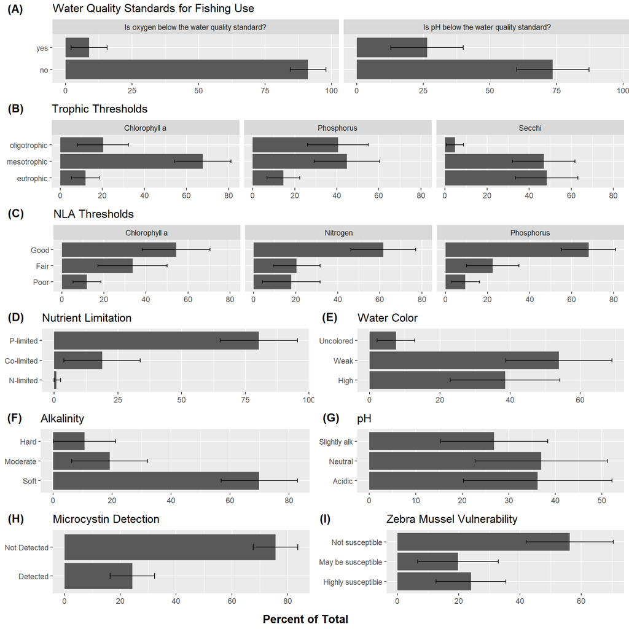

```r
p1<-ggplot(
  table |>
    filter(Indicator %in% c('phos_trophic','chla_trophic','secchi_trophic')) |>
    mutate(Indicator=as.character(Indicator),
           Indicator=ifelse(Indicator=="phos_trophic","Phosphorus",
                            ifelse(Indicator=="chla_trophic","Chlorophyll a",
                                   "Secchi"))) |>
    rename(`Percent of Total`=Estimate.P),
  aes(x=`Percent of Total`,y=Category)) +
  geom_bar(stat="Identity")+
  geom_errorbar(aes(xmin=LCB95Pct.P,xmax=UCB95Pct.P),width=0.2)+
  labs(title="Trophic Thresholds")+
  theme(axis.title.y=element_blank(),axis.title.x=element_blank(),legend.title=element_blank())+
  facet_wrap(.~Indicator)

p2<-ggplot(
  table |>
    filter(Indicator %in% c('chlorophylla_nla','nitrogen_nla','phosphorus_nla')) |>
    mutate(Indicator=as.character(Indicator),
           Indicator=ifelse(Indicator=="chlorophylla_nla","Chlorophyll a",
                            ifelse(Indicator=="nitrogen_nla","Nitrogen",
                                   "Phosphorus"))) |>
    rename(`Percent of Total`=Estimate.P),
  aes(x=`Percent of Total`,y=Category)) +
  geom_bar(stat="Identity")+
  geom_errorbar(aes(xmin=LCB95Pct.P,xmax=UCB95Pct.P),width=0.2)+
  labs(title="NLA Thresholds")+
  theme(axis.title.y=element_blank(),axis.title.x=element_blank(),legend.title=element_blank())+
  facet_wrap(.~Indicator)

p3<-ggplot(
  table |>
    filter(Indicator %in% c('nutrient_limitation')) |>
    rename(`Percent of Total`=Estimate.P),
    aes(x=`Percent of Total`,y=Category)) +
  geom_bar(stat="Identity")+
  geom_errorbar(aes(xmin=LCB95Pct.P,xmax=UCB95Pct.P),width=0.2)+
  labs(title="Nutrient Limitation")+
  theme(axis.title.y=element_blank(),axis.title.x=element_blank(),legend.title=element_blank())

p4<-ggplot(
  table |>
    filter(Indicator %in% c('color')) |>
    rename(`Percent of Total`=Estimate.P),
    aes(x=`Percent of Total`,y=Category)) +
  geom_bar(stat="Identity")+
  geom_errorbar(aes(xmin=LCB95Pct.P,xmax=UCB95Pct.P),width=0.2)+
  labs(title="Water Color")+
  theme(axis.title.y=element_blank(),axis.title.x=element_blank(),legend.title=element_blank())

p5<-ggplot(
  table |>
    filter(Indicator %in% c('alkalinity')) |>
    rename(`Percent of Total`=Estimate.P),
    aes(x=`Percent of Total`,y=Category)) +
  geom_bar(stat="Identity")+
  geom_errorbar(aes(xmin=LCB95Pct.P,xmax=UCB95Pct.P),width=0.2)+
  labs(title="Alkalinity")+
  theme(axis.title.y=element_blank(),axis.title.x=element_blank(),legend.title=element_blank())

p6<-ggplot(
  table |>
    filter(Indicator %in% c('ph_cat')) |>
    rename(`Percent of Total`=Estimate.P),
    aes(x=`Percent of Total`,y=Category)) +
  geom_bar(stat="Identity")+
  geom_errorbar(aes(xmin=LCB95Pct.P,xmax=UCB95Pct.P),width=0.2)+
  labs(title="pH")+
  theme(axis.title.y=element_blank(),axis.title.x=element_blank(),legend.title=element_blank())

p7<-ggplot(
  table |>
    filter(Indicator %in% c('microcystin')) |>
    mutate(Category=ifelse(Category=="Microcystin Detected","Detected","Not Detected")) |>
    rename(`Percent of Total`=Estimate.P),
    aes(x=`Percent of Total`,y=Category)) +
  geom_bar(stat="Identity")+
  geom_errorbar(aes(xmin=LCB95Pct.P,xmax=UCB95Pct.P),width=0.2)+
  labs(title="Microcystin Detection")+
  theme(axis.title.y=element_blank(),axis.title.x=element_blank(),legend.title=element_blank())

p8<-ggplot(
  table |>
    filter(Indicator %in% c('zebra_mussel_vulnerability')) |>
    rename(`Percent of Total`=Estimate.P),
    aes(x=`Percent of Total`,y=Category)) +
  geom_bar(stat="Identity")+
  geom_errorbar(aes(xmin=LCB95Pct.P,xmax=UCB95Pct.P),width=0.2)+
  labs(title="Zebra Mussel Vulnerability")+
  theme(axis.title.y=element_blank(),axis.title.x=element_blank(),legend.title=element_blank())

p9<-ggplot(
  table |>
    filter(Indicator %in% c('dissolved_oxygen_wqs','ph_low_wqs')) |>
    mutate(Indicator=ifelse(Indicator=="dissolved_oxygen_wqs","Is oxygen below the water quality standard?",
                            "Is pH below the water quality standard?")) |>
    mutate(Category=ifelse(Category=="yes","no","yes")) |>
    rename(`Percent of Total`=Estimate.P),
  aes(x=`Percent of Total`,y=Category)) +
  geom_bar(stat="Identity")+
  geom_errorbar(aes(xmin=LCB95Pct.P,xmax=UCB95Pct.P),width=0.2)+
  labs(title="Water Quality Standards for Fishing Use")+
  theme(axis.title.y=element_blank(),axis.title.x=element_blank(),legend.title=element_blank())+
  facet_wrap(.~Indicator)



#arranges all plots together
library(gridExtra)
library(cowplot)

ggdraw() +
  draw_plot(p9, 0.05, .842, 0.96, .16) +
  draw_plot(p1, 0, .675, 1, .167) +
  draw_plot(p2, 0.04, .51, 0.96, .165) +
  draw_plot(p3, 0, 0.35, .5, .16) +
  draw_plot(p4, .5, 0.35, .5, .16) +
  draw_plot(p5, 0, 0.19, .5, .16) +
  draw_plot(p6, .5, 0.19, .5, .16) +
  draw_plot(p7, 0, 0.03, .5, .16) +
  draw_plot(p8, .5, 0.03, .5, .16) +
  draw_plot_label(c("(A)", "(B)", "(C)","(D)","(E)","(F)","(G)","(H)","(I)","Percent of Total"),
                  c(0,0,0, 0, 0.5,0, 0.5,0, 0.5,0.35), c(1,.842, .675, 0.51,0.51, 0.35,0.35, 0.19,0.19,0.03), size = 13)
```

## Comparisons

Compare with NLA and Northern Appalachian.

### Category stacked bar graphs

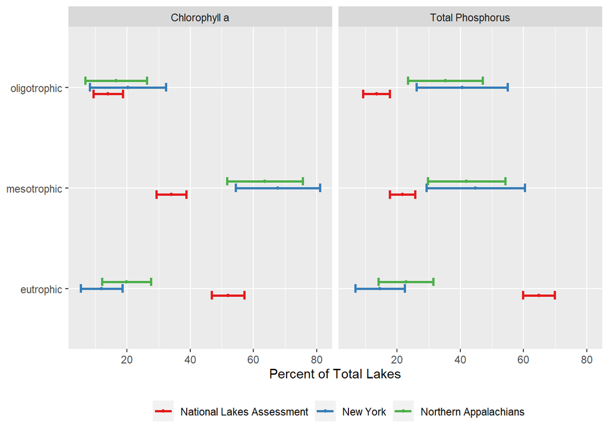

```r
cats <- rbind(ny.cat,nla.cat,nap.cat)



trophic<-cats %>%
  filter(Indicator %in% c("chla_trophic","phos_trophic")) %>%
  mutate(Category=tolower(Category),
         Study=ifelse(Study=="NY","New York",Study),
         Study=ifelse(Study=="NLA","National Lakes Assessment",Study),
         Study=ifelse(Study=="NAP","Northern Appalachians",Study)) |> distinct()


ggplot(trophic |> mutate(Indicator=ifelse(Indicator=="chla_trophic","Chlorophyll a","Total Phosphorus")),aes(y=Category,x=Estimate.P,color=Study))+
  geom_point(position=position_dodge(width=0.2),size=1)+
  theme(axis.title.y=element_blank())+
  theme(legend.position="bottom")+
  theme(legend.title=element_blank())+
  scale_colour_brewer(type="seq",palette="Set1")+
  xlab("Percent of Total Lakes")+
  geom_errorbar(aes(xmin=LCB95Pct.P, xmax=UCB95Pct.P), width=.25, position=position_dodge(width=0.2),size=1)+
   facet_wrap(.~Indicator)
```